# Project 2: Data Mining, Classification, Prediction

Tanish Bhowmick

December 10, 2021

# Mining, Classification, Prediction

## Tanish Bhowmick, tb33385

### Introduction

The dataset below contains the match information of every single match played in the significant pro level ATP tennis tournaments of the year 2021. I further specified the data selected to be targeted towards the statistics describing the winner. More specifically, I selected the length of time in the match, The number of 1st serves made in vs service points won, etc. I am hoping that the data selected below will provide a correlation between specific match statistics, and the likelihood of winning.

```r
library(tidyverse)
library(readr)

urlfile = "https://raw.githubusercontent.com/JeffSackmann/tennis_atp/master/atp_matches_2021.csv"

tennisdataraw <- read_csv(url(urlfile))


keep <- c("tourney_date", "surface", "winner_name", "winner_age",
    "winner_hand", "winner_ht", "minutes", "w_ace", "w_1stIn",
    "w_1stWon", "w_bpSaved", "w_bpFaced", "w_SvGms")
atpdata <- tennisdataraw[keep] %>%
    na.omit
atpdata %>%
    mutate(bpProp = ifelse(((w_bpSaved/w_bpFaced) > 0.5), "Good",
        "Bad")) %>%
    na.omit() -> atpdata
head(atpdata)
```

```
## # A tibble: 6 × 14
##   tourney_date surface winner_name     winner_age winner_hand winner_ht minutes
##          <dbl> <chr>   <chr>                <dbl> <chr>           <dbl>   <dbl>
## 1     20210104 Hard    Hubert Hurkacz        23.9 R                 196      71
## 2     20210104 Hard    Hubert Hurkacz        23.9 R                 196      97
## 3     20210104 Hard    Sebastian Korda       20.5 R                 196      81
## 4     20210104 Hard    Hubert Hurkacz        23.9 R                 196      85
## 5     20210104 Hard    Cameron Norrie        25.4 L                 188     133
## 6     20210104 Hard    Sebastian Korda       20.5 R                 196     111
## # … with 7 more variables: w_ace <dbl>, w_1stIn <dbl>, w_1stWon <dbl>,
## #   w_bpSaved <dbl>, w_bpFaced <dbl>, w_SvGms <dbl>, bpProp <chr>
```

### Cluster Analysis

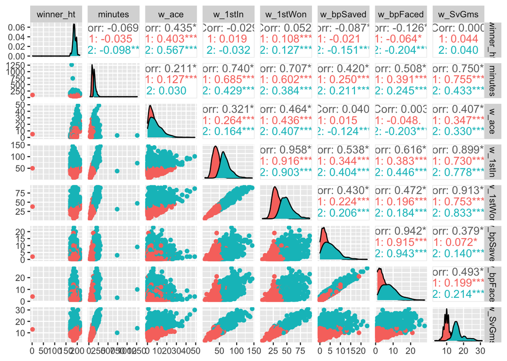

```r
library(cluster)
library(GGally)
set.seed(322)

atpnumdata <- atpdata %>%
    select(6:13)

sil_width <- vector()
for (i in 2:10) {
    kms <- kmeans(atpnumdata, i)
    sil <- silhouette(kms$cluster, dist(atpnumdata))
    sil_width[i] <- mean(sil[, 3])
}
# largest average silhouette when number of clusters is 2

atpcluster <- atpnumdata %>%
    pam(2)
atpnumdata %>%
    mutate(cluster = as.factor(atpcluster$clustering)) %>%
    ggpairs(columns = 1:8, aes(color = cluster))
```

The clustering above shows a comparison of a few different match statistics. The goal of the clustering was to test for correlations between variables such as height and number of service games, 1st serves in and break points faced, etc. The clusters appear to separate most significantly on the basis of the number of 1st serves either made in, or 1st service points won (the most separation in the graphs are showed in these two variables). Overall, we see positive correlations between many of the variables we thought we would, especially when comparing breakpoints saved and faced, as well as 1st serves in and won. However, we can also see certain plots (especially in the height and minutes played categories), skewing the results heavily and making it difficult to pinpoint the exact correlation if there is one at all.

### Dimensionality Reduction with PCA

```r
atppca <- princomp(atpnumdata, cor = T)
atpdf <- data.frame(PC1 = atppca$scores[, 1], PC2 = atppca$scores[,
    2], PC4 = atppca$scores[, 4])
summary(atppca, loadings = "T")
```

```
## Importance of components:
##                          Comp.1    Comp.2    Comp.3     Comp.4     Comp.5
## Standard deviation     2.098866 1.2793949 0.9952371 0.68713034 0.56902638
## Proportion of Variance 0.550655 0.2046064 0.1238121 0.05901851 0.04047388
## Cumulative Proportion  0.550655 0.7552614 0.8790735 0.93809203 0.97856591
##                            Comp.6     Comp.7      Comp.8
## Standard deviation     0.33616527 0.21379261 0.112952752
## Proportion of Variance 0.01412589 0.00571341 0.001594791
## Cumulative Proportion  0.99269180 0.99840521 1.000000000
##
## Loadings:
##           Comp.1 Comp.2 Comp.3 Comp.4 Comp.5 Comp.6 Comp.7 Comp.8
## winner_ht         0.546  0.595  0.578  0.118
## minutes   -0.389        -0.235  0.418 -0.773 -0.145
## w_ace     -0.182  0.589  0.185 -0.675 -0.340        -0.119
## w_1stIn   -0.454        -0.145         0.350 -0.314 -0.500  0.545
## w_1stWon  -0.439  0.181 -0.183         0.343 -0.392  0.256 -0.635
## w_bpSaved -0.323 -0.382  0.519 -0.166        -0.224  0.551  0.313
## w_bpFaced -0.354 -0.393  0.413                0.333 -0.515 -0.414
## w_SvGms   -0.432  0.147 -0.250         0.177  0.751  0.319  0.170
```

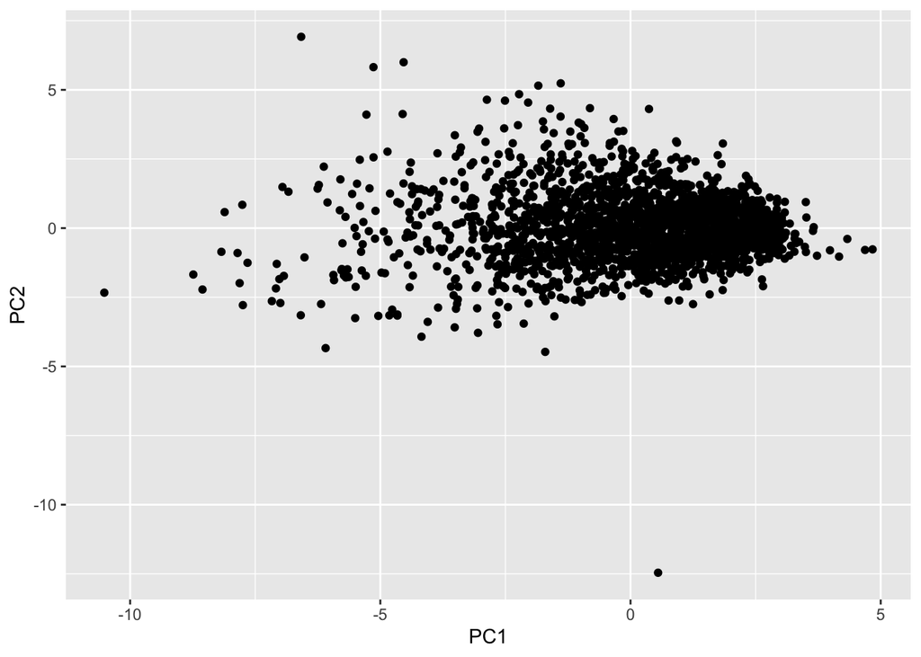

```r
ggplot(atpdf, aes(PC1, PC2)) + geom_point()
```

PC1 is unique in terms of components I have observed before. All the coefficients are of similar relative magnitudes implying that it is a general axis. However, all the loadings are negative, making it a general weakness axis. When there is a higher score on PC1, this means that the player will likely have lower statistics in terms of winning 1st serves and break points and the opposite will be observed with lower PC1 scores. PC2 is a height vs. ace axis. It displays a positive correlation between the two factors, meaning that a player who is taller is more likely to have more aces and a higher PC2 score indicates higher stats for both variables. This component makes sense because in the sport of tennis, it a common conception that a taller player will have access to better angles on their serve allowing for a more effective serve.

The plot shows a neutral correlation between Principal Component 1 and Principal Component 2. This is likely due to the fact that the variables of height and ace proportion could potentially be independent from other parts of their game. The general strength of a players game may have little to do with their actual height and serving ability. That is what leads to the largely neutral correlation observed in the plot.

### Linear Classifier

```r
atplinvalues <- atpdata %>%
    select(4:14) %>%
    select(-c(1:4, 6, 9, 10))

fit <- glm(bpProp == "Good" ~ ., data = atplinvalues, family = "binomial")
score <- predict(fit, type = "response")
class_diag(score, truth = atplinvalues$bpProp, positive = "Good")
```

```
##            acc   sens   spec    ppv     f1     ba    auc
## Metrics 0.8468 0.8974 0.7264 0.8865 0.8919 0.8119 0.9048
```

```r
table(truth = atplinvalues$bpProp, predictions = score > 0.5)
```

```
##       predictions
## truth  FALSE TRUE
##   Bad    446  168
##   Good   150 1312
```

```r
set.seed(1234)
k = 10

data <- atplinvalues[sample(nrow(atplinvalues)), ]
folds <- cut(seq(1:nrow(atplinvalues)), breaks = k, labels = F)
diags <- NULL
for (i in 1:k) {
    train <- data[folds != i, ]
    test <- data[folds == i, ]
    truth <- test$bpProp
    fit <- glm(bpProp == "Good" ~ ., data = train, family = "binomial")
    probs <- predict(fit, newdata = test, type = "response")
    diags <- rbind(diags, class_diag(probs, truth, positive = "Good"))
}
summarize_all(diags, mean)
```

```
##       acc    sens    spec     ppv      f1      ba     auc
## 1 0.84732 0.89893 0.72447 0.88585 0.89216 0.81171 0.90345
```

While I was creating my atpdata set, I created a new variable from the pre-existing ones called bpProp. This translates to the proportion of break points one (it is the ratio of break points saved to break points faced). I made the standard for a good bpProp >0.5 so that the player should have to win more than half the breakpoints they face to prove their own ability.

In the process of training the dataset, we get metrics such as accuracy, sensitivity (True Positive Rate), specificity (True Negative Rate), and precision. All of these values listed above are quite high both when training the data and cross-validating, implying the existence of a strong model. Another indicator of the accuracy of the model is the fact that the values for both training and cross-validation are in similar ranges, meaning that the model is good at predicting unseen data. There are no signs of overfitting data. The AUC is also very high at approximately 90% meaning there is a high classification accuracy. Overall the model is quite accurate in predicting data.

### Non-Parametric Classifier

```r
library(caret)
knn_fit <- knn3(bpProp == "Good" ~ ., data = atplinvalues, k = 5)

y_hat_knn <- predict(knn_fit, atplinvalues)

class_diag(y_hat_knn[, 2], atplinvalues$bpProp, positive = "Good")
```

```
##            acc   sens   spec    ppv     f1     ba    auc
## Metrics 0.8516 0.9152 0.7003 0.8791 0.8968 0.8078 0.9254
```

```r
table(truth = atplinvalues$bpProp, predictions = y_hat_knn[,
    2] > 0.5)
```

```
##       predictions
## truth  FALSE TRUE
##   Bad    430  184
##   Good   124 1338
```

```r
set.seed(1234)
k2 = 10

data2 <- atplinvalues[sample(nrow(atplinvalues)), ]
folds2 <- cut(seq(1:nrow(atplinvalues)), breaks = k2, labels = F)

diags2 <- NULL
for (i in 1:k) {
    train2 <- data2[folds2 != i, ]
    test2 <- data2[folds2 == i, ]
    truth2 <- test2$bpProp
    fit2 <- knn3(bpProp ~ ., data = train2)
    probs2 <- predict(fit2, newdata = test2)[, 1]
    diags2 <- rbind(diags, class_diag(probs2, truth2, positive = "Good"))
}
summarize_all(diags2, mean)
```

```
##         acc   sens      spec       ppv     f1        ba       auc
## 1 0.7877727 0.8271 0.6943727 0.8327636 0.8256 0.7607455 0.8336545
```

The metrics produced through the non-parametric classification method definitely show varied results when compared to the linear classifier above. The training data for the non-parametric classifier shows optimistic results, with higher AUC and accuracy values as well as other metrics in the same general range as the linear classifier data. However, the cross-validation data shows far lower values for the metrics, implying that the model does a poor job of predicting unseen data, unlike the linear classifier coded above. The AUC value for the cross-validation decreased significantly (still with a strong level of classification but still not as high functioning as the linear classifier).

### Regression/Numeric Prediction

```r
fit <- lm(w_SvGms ~ ., data = atpnumdata)
yhat <- predict(fit)

# MSE
mean((atpnumdata$w_SvGms - yhat)^2)
```

```
## [1] 1.838372
```

```r
set.seed(1234)
k3 = 5
data3 <- atpnumdata[sample(nrow(atpnumdata)), ]
folds3 <- cut(seq(1:nrow(atpnumdata)), breaks = k, labels = F)

diags3 <- NULL
for (i in 1:k) {
    train3 <- data3[folds3 != i, ]
    test3 <- data3[folds3 == i, ]
    ## Fit linear regression model to training set
    fit3 <- lm(w_SvGms ~ ., data = train3)
    ## Get predictions/y-hats on test set (fold i)
    yhat <- predict(fit3, newdata = test3)
    ## Compute prediction error (MSE) for fold i
    diags3 <- mean((test3$w_SvGms - yhat)^2)
}
mean(diags3)
```

```
## [1] 5.241936
```

For this regression and numerical prediction section, I tried to create a model meant to predict the number of service games for a player in a match and did this against the remaining numerical data in the dataset. The MSE for the overall data was relatively small with a value of only about 1.84. However, when taking the MSE of the cross-validation data, the MSE value increased significantly to about 5.24 indicating that there is signficant overfitting in the model. However, 5.24 isn’t the worst value for MSE possible so the cross-validation is still sufficient, but perhaps not the best.

### Python

```r
library(reticulate)
use_python("/usr/bin/python3", required = F)
ht_srv <- atpnumdata %>%
    select(c("winner_ht", "w_SvGms"))
```

```python
import numpy
# Python chunk
htarray = numpy.array(r.ht_srv['winner_ht'])
servearray = numpy.array(r.ht_srv['w_SvGms'])
htarray.max()
```

```
## 211.0
```

```python
servearray.mean()
```

```
## 13.049132947976879
```

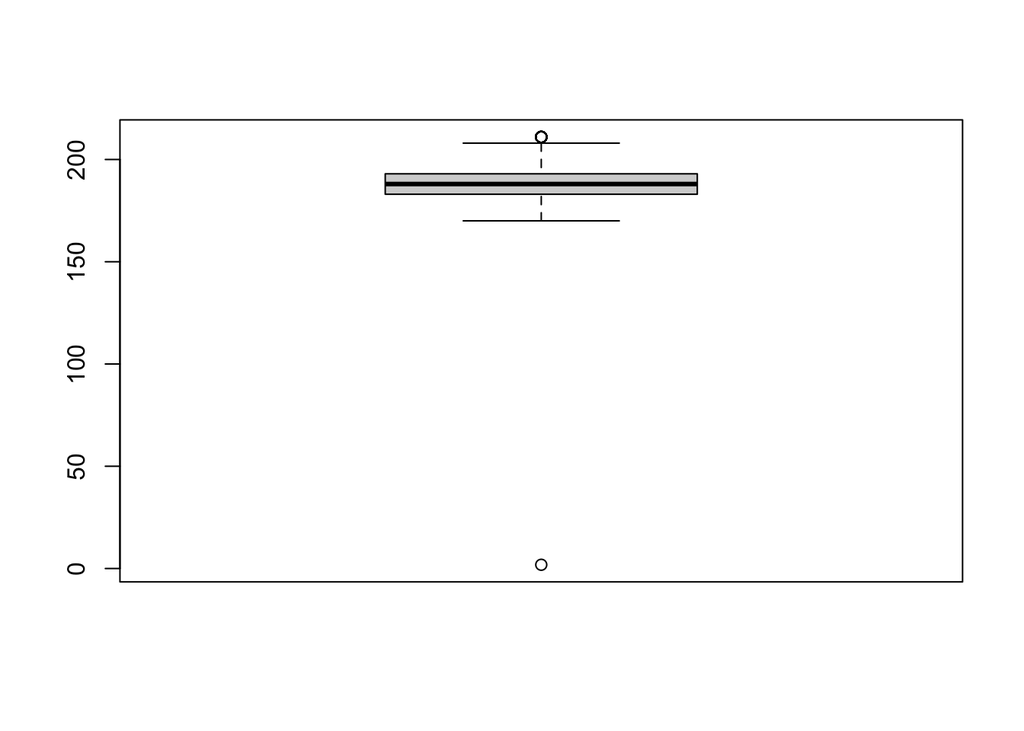

```r
# Back to R
boxplot(py$htarray)
```